# Supervised Learning

## Assignment for Supersvised Learning

Name: Preneeth O  
Batch: 12

## Introduction

Build a model for a bank to find among the existing customer who will be prospective customer to avail personal loans .

### Import all the necessary libraries

```python
#Load Libraries
import pandas as pd
import numpy as np
import matplotlib as mpl
import matplotlib.pyplot as plt
from sklearn.cross_validation import train_test_split

import statsmodels.api as sm
from sklearn import metrics
from sklearn import datasets
import seaborn as sn
from sklearn.linear_model import LogisticRegression
from sklearn.naive_bayes import GaussianNB
from sklearn.neighbors import KNeighborsClassifier
from sklearn import svm
from sklearn.metrics import classification_report
from sklearn.metrics import roc_auc_score
from sklearn.metrics import roc_curve
from sklearn.metrics import accuracy_score
from scipy.stats import zscore

%matplotlib inline

sn.set(color_codes = True)
```

### Read data from CSV from file

```python
dataFrame = pd.read_csv('Bank_Personal_Loan_Modelling.csv')
dataFrame.head()
```

|  | ID | Age | Experience | Income | ZIP Code | Family | CCAvg | Education | Mortgage | Personal Loan | Securities Account | CD Account | Online | CreditCard |
| --- | --- | --- | --- | --- | --- | --- | --- | --- | --- | --- | --- | --- | --- | --- |
| 0 | 1 | 25 | 1 | 49 | 91107 | 4 | 1.6 | 1 | 0 | 0 | 1 | 0 | 0 | 0 |
| 1 | 2 | 45 | 19 | 34 | 90089 | 3 | 1.5 | 1 | 0 | 0 | 1 | 0 | 0 | 0 |
| 2 | 3 | 39 | 15 | 11 | 94720 | 1 | 1.0 | 1 | 0 | 0 | 0 | 0 | 0 | 0 |
| 3 | 4 | 35 | 9 | 100 | 94112 | 1 | 2.7 | 2 | 0 | 0 | 0 | 0 | 0 | 0 |
| 4 | 5 | 35 | 8 | 45 | 91330 | 4 | 1.0 | 2 | 0 | 0 | 0 | 0 | 0 | 1 |

### Basic EDA

- Find the shape of the data & various columns
- Check the presence of missing values
- Understand the values in each column
- Descriptive stats of numerical columns
- Find the distribution of numerical columns and presence of outliers
- Distribution of categorical columns

```python
#Shape and column names
print(dataFrame.shape)
print (list(dataFrame.columns))
```

```
(5000, 14)
['ID', 'Age', 'Experience', 'Income', 'ZIP Code', 'Family', 'CCAvg', 'Education', 'Mortgage', 'Personal Loan', 'Securities Account', 'CD Account', 'Online', 'CreditCard']
```

**Findings:** There are 5000 rows and 14 columns

```python
#Rename column names where there are spaces
dataFrame = dataFrame.rename(columns={'ZIP Code':'ZIP_Code','Personal Loan': 'Personal_Loan', 'Securities Account': 'Securities_Account', 'CD Account' : 'CD_Account'})
```

```python
#Check for missing values & data types
dataFrame.info()
```

```
<class 'pandas.core.frame.DataFrame'>
RangeIndex: 5000 entries, 0 to 4999
Data columns (total 14 columns):
ID                    5000 non-null int64
Age                   5000 non-null int64
Experience            5000 non-null int64
Income                5000 non-null int64
ZIP_Code              5000 non-null int64
Family                5000 non-null int64
CCAvg                 5000 non-null float64
Education             5000 non-null int64
Mortgage              5000 non-null int64
Personal_Loan         5000 non-null int64
Securities_Account    5000 non-null int64
CD_Account            5000 non-null int64
Online                5000 non-null int64
CreditCard            5000 non-null int64
dtypes: float64(1), int64(13)
memory usage: 547.0 KB
```

**Findings:** All are numeric data and there are no nulls or missing values.

```python
#Understand each column values

print ("Family : ")
print (*list(dataFrame.Family.unique()))

print ("Education : ")
print (*list(dataFrame.Education.unique()))

print ("Securities Account : ")
print (*list(dataFrame.Securities_Account.unique()))

print ("CD Account : ")
print (*list(dataFrame.CD_Account.unique()))

print ("Online : ")
print (*list(dataFrame.Online.unique()))

print ("CreditCard : ")
print (*list(dataFrame.CreditCard.unique()))

print ("Zip Code unique values count : ")
print ((len((dataFrame.ZIP_Code.unique()))))
```

```
Family :
4 3 1 2
Education :
1 2 3
Securities Account :
1 0
CD Account :
0 1
Online :
0 1
CreditCard :
0 1
Zip Code unique values count :
467
```

| Col Name | Description | Type | Data Type | Categorical Attributes | Remarks |
| --- | --- | --- | --- | --- | --- |
| ID | Customer ID | Indepenent Variable | Numeric | No |  |
| Age | Customer's age in completed years | Indepenent Variable | Numeric | No |  |
| Experience | #years of professional experience | Indepenent Variable | Numeric | No |  |
| Income | Annual income of the customer ($000) | Indepenent Variable | Numeric | No |  |
| ZIP Code | Home Address ZIP code. | Indepenent Variable | Numeric | Yes | There 467 unique zip code values. |
| Family | Family size of the customer | Indepenent Variable | Numeric | Yes | Family size varies from 1 to 4 |
| CCAvg | Avg. spending on credit cards per month ($000) | Indepenent Variable | Numeric | No |  |
| Education | Education Level. | Indepenent Variable | Numeric | Yes | 1: Undergrad; 2: Graduate; 3: Advanced/Professional |
| Mortgage | Value of house mortgage if any. ($000) | Indepenent Variable | Numeric | No |  |
| Securities Account | Does the customer have a securities account with the bank? | Indepenent Variable | Numeric | Yes | 0 - Security Account Not Available; 1 - Security Account Available |
| CD Account | Does the customer have a certificate of deposit (CD) account with the bank? | Indepenent Variable | Numeric | Yes | 0 - CD Account Not Available; 1 - CD Account Available |
| Online | Does the customer use internet banking facilities? | Indepenent Variable | Numeric | Yes | 0 - Internet Banking Not Available; 1 - Internet Banking Available |
| Credit card | Does the customer use a credit card issued by UniversalBank? | Indepenent Variable | Numeric | Yes | 0 - Internet Banking Not Available; 1 - Internet Banking Available |
| Personal Loan | Did this customer accept the personal loan offered in the last campaign? | Dependent Variable (Target) | Numeric | Yes | 0 - Personal Loan not Availed; 1 - Personal Loan Availed |

**Findings:**

```
* All are numeric columns
* No missing data
* There are 7 Categorical variables and values of each column is listed in above table.
* Personal Loan is the Target Variable.
* ID column will not have any significance.
```

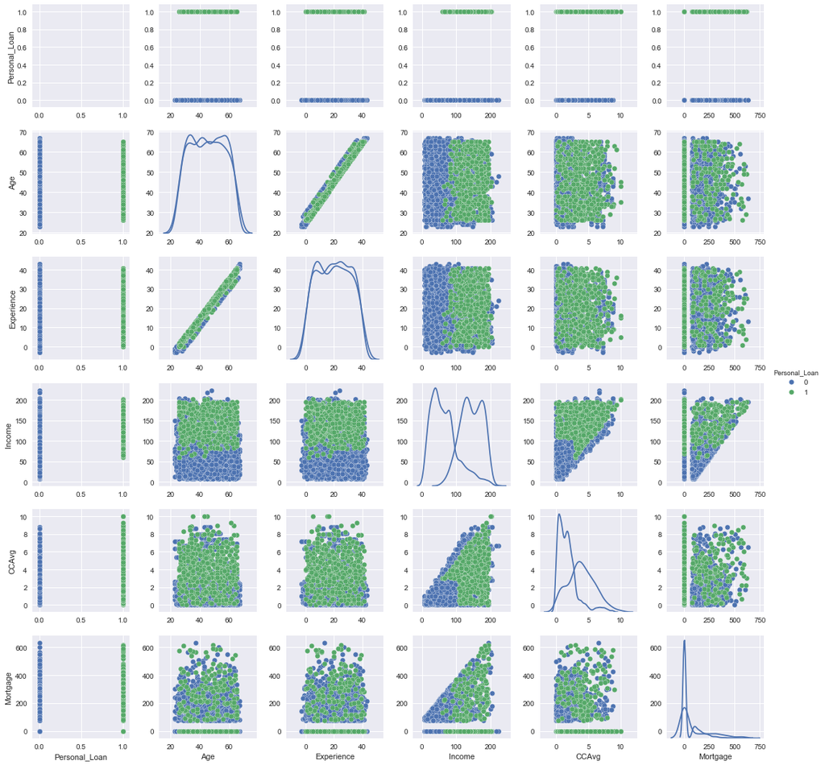

```python
#Find the relation between continous variables

sn.pairplot(dataFrame, hue="Personal_Loan", diag_kind="kde", \
            vars=['Personal_Loan','Age', 'Experience','Income', 'CCAvg',  'Mortgage'])
```

**Findings:**

[output not shown]

```python
# five point summary of the continuous attributes
dataFrame[[ 'Experience','Income', 'CCAvg',  'Mortgage']].describe().T
```

|  | count | mean | std | min | 25% | 50% | 75% | max |
| --- | --- | --- | --- | --- | --- | --- | --- | --- |
| Experience | 5000.0 | 20.104600 | 11.467954 | -3.0 | 10.0 | 20.0 | 30.0 | 43.0 |
| Income | 5000.0 | 73.774200 | 46.033729 | 8.0 | 39.0 | 64.0 | 98.0 | 224.0 |
| CCAvg | 5000.0 | 1.937938 | 1.747659 | 0.0 | 0.7 | 1.5 | 2.5 | 10.0 |
| Mortgage | 5000.0 | 56.498800 | 101.713802 | 0.0 | 0.0 | 0.0 | 101.0 | 635.0 |

**Findings:**

```
* Overall data looks fine
* In Experience column there is -ve values which is incorrect.
```

```python
#Find the records where experience is in -ve
len(dataFrame[dataFrame['Experience'] < 0 ])

#There are 52 records with incorrect exprience. so replace it with zero
dataFrame.loc[(dataFrame['Experience'] < 0),'Experience'] = 0
```

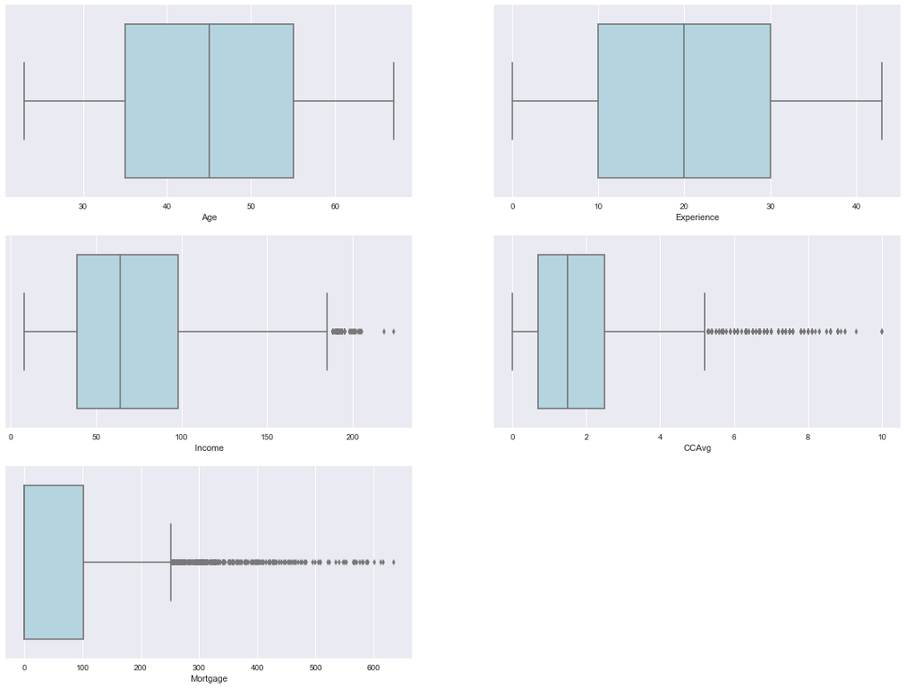

```python
# Plot continuous attributes for outliers

plt.figure(figsize= (20,15))
plt.subplot(3,2,1)
sn.boxplot(x= dataFrame.Age, color='lightblue')

plt.subplot(3,2,2)
sn.boxplot(x= dataFrame.Experience, color='lightblue')

plt.subplot(3,2,3)
sn.boxplot(x= dataFrame.Income, color='lightblue')

plt.subplot(3,2,4)
sn.boxplot(x= dataFrame.CCAvg, color='lightblue')

plt.subplot(3,2,5)
sn.boxplot(x= dataFrame.Mortgage, color='lightblue')

plt.show()
```

**Findings:**

[output not shown]

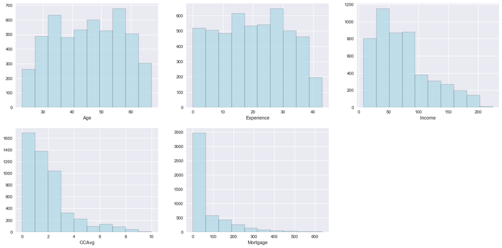

```python
#Plots to see the distribution of the continuous features individually

def plotDistrubtion(col, pos):
    plt.subplot(3,3,pos)
    plt.hist(col, color='lightblue', edgecolor = 'black', alpha = 0.7)
    plt.xlabel(col.name)

plt.figure(figsize= (20,15))

plotDistrubtion(dataFrame.Age, 1)
plotDistrubtion(dataFrame.Experience, 2)
plotDistrubtion(dataFrame.Income, 3)
plotDistrubtion(dataFrame.CCAvg,4)
plotDistrubtion(dataFrame.Mortgage, 5)


plt.show()
```

**Findings:**

```
* Income, CCAvg, & Mortgage data are right skewed.
```

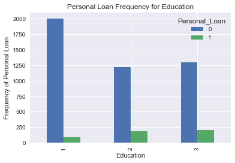

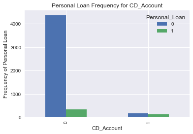

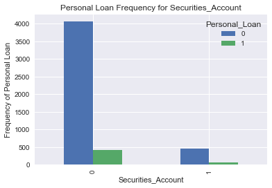

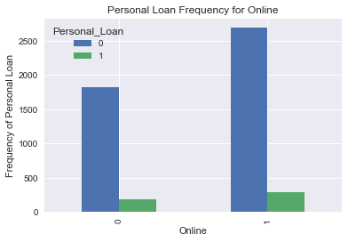

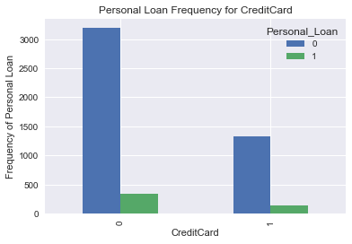

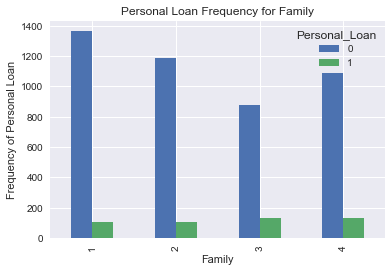

[figure not shown]

```python
#Plots to see the distribution of the categorical features individually

def comparisionWithPersonalLoan(col, pos):
    pd.crosstab(col,dataFrame.Personal_Loan).plot(kind='bar')
    #plt.subplot(3,3,pos)
    plt.title('Personal Loan Frequency for '+ col.name)
    plt.xlabel(col.name)
    plt.ylabel('Frequency of Personal Loan')


plt.figure(figsize= (20,80))
comparisionWithPersonalLoan(dataFrame.Education, 1)
comparisionWithPersonalLoan(dataFrame.CD_Account, 2)
comparisionWithPersonalLoan(dataFrame.Securities_Account, 3)
comparisionWithPersonalLoan(dataFrame.Online,4)
comparisionWithPersonalLoan(dataFrame.CreditCard,5)
comparisionWithPersonalLoan(dataFrame.Family,6)
comparisionWithPersonalLoan(dataFrame.ZIP_Code,7)
#comparisionWithPersonalLoan(dataFrame.ID,7)
plt.show()
```

```python
#Explore Personal_Loan classification
dataFrame.Personal_Loan.value_counts()
```

```
0    4520
1     480
Name: Personal_Loan, dtype: int64
```

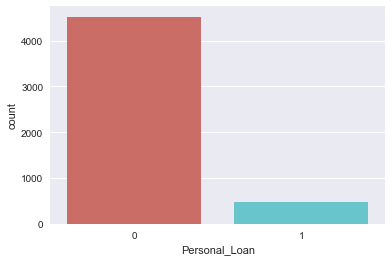

```python
sn.countplot(x='Personal_Loan', data=dataFrame, palette='hls')
```

```python
count_loan = len(dataFrame[dataFrame['Personal_Loan']==1])
count_no_loan = len(dataFrame[dataFrame['Personal_Loan']==0])
per_loan = count_loan/(count_loan+count_no_loan)
print("percentage of loans availed = ", per_loan*100)
per_no_loan = count_no_loan/(count_no_loan+count_loan)
print("percentage of loans not availed", per_no_loan*100)
```

```
percentage of loans availed =  9.6
percentage of loans not availed 90.4
```

```python
dataFrame.groupby(["Personal_Loan"]).mean()
```

| Personal_Loan | ID | Age | Experience | Income | ZIP_Code | Family | CCAvg | Education | Mortgage | Securities_Account | CD_Account | Online | CreditCard |
| --- | --- | --- | --- | --- | --- | --- | --- | --- | --- | --- | --- | --- | --- |
| 0 | 2512.165487 | 45.367257 | 20.148894 | 66.237389 | 93152.428761 | 2.373451 | 1.729009 | 1.843584 | 51.789381 | 0.102212 | 0.035841 | 0.595796 | 0.293584 |
| 1 | 2390.650000 | 45.066667 | 19.843750 | 144.745833 | 93153.202083 | 2.612500 | 3.905354 | 2.233333 | 100.845833 | 0.125000 | 0.291667 | 0.606250 | 0.297917 |

**Findings:**

[output not shown]

### Adding dummy variables for Categorical columns

```python
cat_vars=['Family','Education','Securities_Account','CD_Account','Online','CreditCard']
for var in cat_vars:
    cat_list='var'+'_'+var
    cat_list = pd.get_dummies(dataFrame[var], prefix=var)
    data1=dataFrame.join(cat_list)
    dataFrame=data1
cat_vars=['Family','Education','Securities_Account','CD_Account','Online','CreditCard']
data_vars=dataFrame.columns.values.tolist()
to_keep=[i for i in data_vars if i not in cat_vars]
data_final=dataFrame[to_keep]
data_final.columns.values
```

```
array(['ID', 'Age', 'Experience', 'Income', 'ZIP_Code', 'CCAvg',
       'Mortgage', 'Personal_Loan', 'Family_1', 'Family_2', 'Family_3',
       'Family_4', 'Education_1', 'Education_2', 'Education_3',
       'Securities_Account_0', 'Securities_Account_1', 'CD_Account_0',
       'CD_Account_1', 'Online_0', 'Online_1', 'CreditCard_0',
       'CreditCard_1'], dtype=object)
```

```python
#Remove attributes which doesnot play significant role in predecting the class.

data_final = data_final.drop(['ID'], axis=1)
#Zip code is removed bcos there 400+ zip codes values. which may not play significant role.
#If there was option to categorize in small groups then we could have considered zip code.
data_final = data_final.drop(['ZIP_Code'], axis=1)
#data_final = data_final.drop(['Family_1'], axis=1)
#data_final = data_final.drop(['Education_1'], axis=1)
#data_final = data_final.drop(['CD_Account_0'], axis=1)
#data_final = data_final.drop(['Online_0'], axis=1)
#data_final = data_final.drop(['CreditCard_0'], axis=1)
```

```python
#Split the data into train & test data sets
X = data_final.loc[:, data_final.columns != 'Personal_Loan']
y = data_final.loc[:, data_final.columns == 'Personal_Loan']

X_train, X_test, y_train, y_test = train_test_split(X, y, test_size=0.30, random_state=7)

# convert all attributes to Z scale
X_train = X_train.apply(zscore)
X_test = X_test.apply(zscore)
```

### 1. Using Logistic Regression Model

```python
# A generic function to execute model, calculate model score and print confusion matrix
def executeModel(model, X_train, y_train ):
    model.fit(X_train, y_train.values.ravel())
    y_predict = model.predict(X_test)

    model_score = model.score(X_test, y_test)
    print(model_score)
    print(metrics.confusion_matrix(y_test, y_predict))
    print('Accuracy model on test set: {:.2f}'.format(model_score))

    print(classification_report(y_test, y_predict))

# A generic method to plot ROC curve
def plotROC(tmpmodel, X_train, y_train, name):
    roc_auc = roc_auc_score(y_test, tmpmodel.predict(X_test))
    fpr, tpr, thresholds = roc_curve(y_test, tmpmodel.predict_proba(X_test)[:,1])
    plt.figure()
    plt.plot(fpr, tpr, label= name+' (auc = %0.2f)' % roc_auc)
    plt.plot([0, 1], [0, 1],'r--')
    plt.xlim([0.0, 1.0])
    plt.ylim([0.0, 1.05])
    plt.xlabel('False Positive Rate')
    plt.ylabel('True Positive Rate')
    plt.title('Receiver operating characteristic')
    plt.legend(loc="lower right")
    plt.show()
```

```python
# Fit the Logistic Regression Model
model_log_Reg = LogisticRegression()
executeModel (model_log_Reg, X_train, y_train)
```

```
0.964
[[1351   11]
 [  43   95]]
Accuracy model on test set: 0.96
             precision    recall  f1-score   support

          0       0.97      0.99      0.98      1362
          1       0.90      0.69      0.78       138

avg / total       0.96      0.96      0.96      1500
```

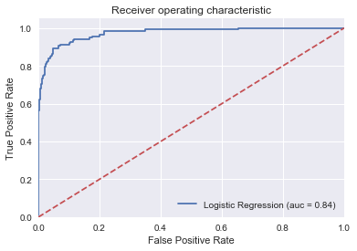

```python
plotROC(model_log_Reg,X_train, y_train, "Logistic Regression")
```

**Logistic Regression Findings:**

```
* Model Accuracy is looking good at 0.96.
* The F-score or F-measure is 0.96, which is very good.
* ROC curve stays way away from the line and it is almost pointing towards top left corner and AUC is 0.84, which implies that model has performed well.
```

### 2. Using Naive Bayes Model

```python
# Fit the Naive Bayes Model
nb_model = GaussianNB()
executeModel (nb_model, X_train, y_train)
```

```
0.893333333333
[[1267   95]
 [  65   73]]
Accuracy model on test set: 0.89
             precision    recall  f1-score   support

          0       0.95      0.93      0.94      1362
          1       0.43      0.53      0.48       138

avg / total       0.90      0.89      0.90      1500
```

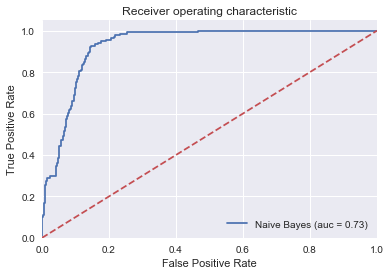

```python
plotROC(nb_model,X_train, y_train, "Naive Bayes")
```

**Naive Bayes Model - Findings:**

```
* Model Accuracy is looking good at 0.89.
* The F-score or F-measure is 0.90.
* ROC curve stays way away from the line and it is almost pointing towards top left corner and AUC is 0.73, which implies that model has performed well.
* Logistic Regression Model has performed better than Naive Bayes.
```

### 3. Using KNN Model

```python
# Fit the KNN Model
knn_model = KNeighborsClassifier(n_neighbors= 3 , weights = 'distance' )
executeModel (knn_model, X_train, y_train)
```

```
0.962666666667
[[1353    9]
 [  47   91]]
Accuracy model on test set: 0.96
             precision    recall  f1-score   support

          0       0.97      0.99      0.98      1362
          1       0.91      0.66      0.76       138

avg / total       0.96      0.96      0.96      1500
```

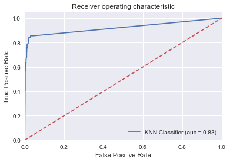

```python
plotROC(knn_model, X_train, y_train, "KNN Classifier")
```

```python
#Find optional K value.

# creating odd list of K for KNN
myList = list(range(1,30))

# subsetting just the odd ones
neighbors = list(filter(lambda x: x % 2 != 0, myList))

# empty list that will hold accuracy scores
ac_scores = []

# perform accuracy metrics for values from 1,3,5....19
for k in neighbors:
    knn = KNeighborsClassifier(n_neighbors=k)
    knn.fit(X_train, y_train)
    # predict the response
    y_pred = knn.predict(X_test)
    # evaluate accuracy
    scores = accuracy_score(y_test, y_pred)
    ac_scores.append(scores)

# changing to misclassification error
MSE = [1 - x for x in ac_scores]

# determining best k
optimal_k = neighbors[MSE.index(min(MSE))]
print("The optimal number of neighbors is %d" % optimal_k)
```

```
The optimal number of neighbors is 1
```

```
0.965333333333
[[1344   18]
 [  34  104]]
Accuracy model on test set: 0.97
             precision    recall  f1-score   support

          0       0.98      0.99      0.98      1362
          1       0.85      0.75      0.80       138

avg / total       0.96      0.97      0.96      1500
```

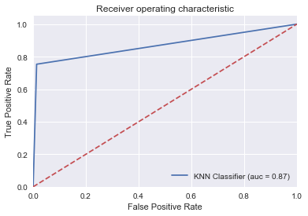

```python
# Run the model again with optimal K value
knn_model = KNeighborsClassifier(n_neighbors= optimal_k , weights = 'distance' )
executeModel (knn_model, X_train, y_train)
plotROC(knn_model, X_train, y_train, "KNN Classifier")
```

**KNN Model - Findings:**

```
* Model Accuracy is looking good at .96.
* The F-score or F-measure is 0.96.
* ROC curve stays way away from the line and it is almost pointing towards top left corner and AUC is 0.87.
* KNN has performed better than Logistic Regression Model & Naive Bayes.
```

### 4. Using SVM Model

```python
# Fit the SVM Model

svm_model = svm.SVC(gamma=0.025, C=3, probability=True)
executeModel (svm_model, X_train, y_train)
```

```
0.983333333333
[[1358    4]
 [  21  117]]
Accuracy model on test set: 0.98
             precision    recall  f1-score   support

          0       0.98      1.00      0.99      1362
          1       0.97      0.85      0.90       138

avg / total       0.98      0.98      0.98      1500
```

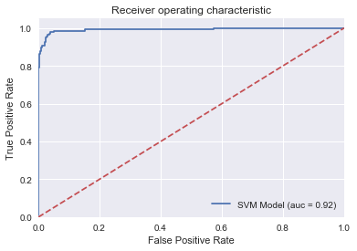

```python
plotROC(svm_model, X_train, y_train, "SVM Model")
```

**SVM Model - Findings:**

```
* Model Accuracy is looking good at .98.
* The F-score or F-measure is 0.98.
* ROC curve stays way away from the line and it is almost pointing towards top left corner and AUC is 0.92.
* SVM out performed all other models.
```

### Comparision of Classification Models Performance

| Model | Accuracy | F1-Score | AUC |
| --- | --- | --- | --- |
| Logistic Regresssion | .96 | .96 | 0.84 |
| Naive Bayes Classifier | .89 | .90 | 0.73 |
| KNN Classifier | .96 | .96 | 0.87 |
| SVM Classifier | .98 | .98 | 0.92 |

#### From the above table we can conclude that SVM Classifier is yeilding better results when compared to other 3 models